# SOTA 2017-18, stats for Annette

V1, last updated January 9, 2019

### Things to know

- Key points for each section will be indicated with a “Takeways” header. The basis of the prose describing the data can be built around these.
- More detailed numbers are available upon request (e.g. tables of what’s shown in figures).
- The status of sections will be updated as they are ready to write:
  - “Ready to write” - self-explanatory
  - “In progress” - writing can begin, but numbers may slightly change or a figure may be added
  - “TBA” - analysis in progress on the back end; no content currently available
- Table numbers are way off right now; don’t worry about it.

**Known issues (for Emily):**

- Partnerships - pending programs: Need to fix program types from pending partners
- Network considerations: Should AUSL/ISP also be split by HS/ES?
- Network outliers: How should combo schools be handled? New networks lump ES and HS together.

### Table of Contents

- Section I: Key Findings (TBA)
- Section II: Arts Ed Plan Goals (TBA)
- Section III: District Information (all ready to write)
  - III-A: Survey Participation
  - III-A: Creative Schools Certifications
  - III-B: Staffing
  - III-C: Minutes of Instruction
  - III-D: Access
  - III-E: Disciplines and Depth
  - III-F: Additional Arts Assets
- Section IV: Partnerships (mixed)
  - IV-A: Partnership distribution (mostly ready to write, one TBA analysis)
  - Iv-B: Programming (in progress)
- Section V: Network Analyses (TBA)
- Section VI: Funding (TBA)
- Section VII: Conclusion (TBA)

### Section I: Key Findings

Jump back to top

TBA

[figure not shown]

### Section II: Arts Ed Plan Goals

Jump back to top

TBA

### Section III: District Information

Jump back to top

- Number of Schools: **650**
  - Elementary Schools: **480**
  - High Schools: **170**
- Number of K-12 Students (per CPS 20th day membership file): **351,941**

#### III-A: Creative Schools Survey Participation

Jump back to top

**Takeaways:**

- District-wide, nearly same participation level as previous year (96% vs. 97%).
- 100% participation from district-run schools (first time ever!)
- A drop in charter/contract/options participation.

Table 2: Survey completion rate by year, district overall

| SchoolYear | Status | Num | N | Percent |
| --- | --- | --- | --- | --- |
| 2017-18 | Complete | 627 | 650 | 96% |
| 2017-18 | Incomplete | 23 | 650 | 4% |
| 2016-17 | Complete | 631 | 653 | 97% |
| 2016-17 | Incomplete | 22 | 653 | 3% |
| 2015-16 | Complete | 580 | 660 | 88% |
| 2015-16 | Incomplete | 80 | 660 | 12% |
| 2014-15 | Complete | 571 | 664 | 86% |
| 2014-15 | Incomplete | 93 | 664 | 14% |
| 2013-14 | Complete | 585 | 664 | 88% |
| 2013-14 | Incomplete | 79 | 664 | 12% |
| 2012-13 | Complete | 387 | 681 | 57% |
| 2012-13 | Incomplete | 294 | 681 | 43% |

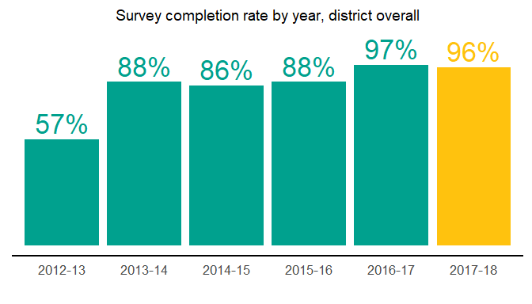

Table 3: Survey completion rate by year, ES and HS

| SchoolYear | SchoolType | Status | Num | N | Percent |
| --- | --- | --- | --- | --- | --- |
| 2012-13 | ES | Complete | 316 | 527 | 60% |
| 2012-13 | HS | Complete | 71 | 154 | 46% |
| 2013-14 | ES | Complete | 461 | 485 | 95% |
| 2013-14 | HS | Complete | 124 | 179 | 69% |
| 2014-15 | ES | Complete | 443 | 483 | 92% |
| 2014-15 | HS | Complete | 128 | 181 | 71% |
| 2015-16 | ES | Complete | 451 | 484 | 93% |
| 2015-16 | HS | Complete | 129 | 176 | 73% |
| 2016-17 | ES | Complete | 478 | 481 | 99% |
| 2016-17 | HS | Complete | 153 | 172 | 89% |
| 2017-18 | ES | Complete | 477 | 480 | 99% |
| 2017-18 | HS | Complete | 150 | 170 | 88% |

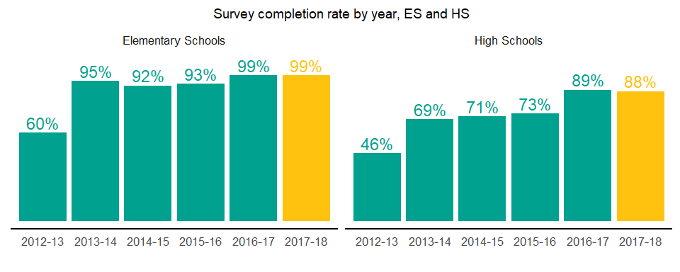

Table 4: Survey completion rate by year: District-run, Charter, Options

| SchoolYear | SchoolType | Status | Num | N | Percent |
| --- | --- | --- | --- | --- | --- |
| 2012-13 | Charter & Contract | Complete | 8 | 97 | 8% |
| 2012-13 | Charter & Contract | Incomplete | 89 | 97 | 92% |
| 2012-13 | District-Run | Complete | 366 | 523 | 70% |
| 2012-13 | District-Run | Incomplete | 157 | 523 | 30% |
| 2012-13 | NA | Incomplete | 43 | 55 | 78% |
| 2012-13 | NA | Complete | 12 | 55 | 22% |
| 2012-13 | Options & Other | Complete | 1 | 6 | 17% |
| 2012-13 | Options & Other | Incomplete | 5 | 6 | 83% |
| 2013-14 | Charter & Contract | Complete | 59 | 107 | 55% |
| 2013-14 | Charter & Contract | Incomplete | 48 | 107 | 45% |
| 2013-14 | District-Run | Incomplete | 7 | 526 | 1% |
| 2013-14 | District-Run | Complete | 519 | 526 | 99% |
| 2013-14 | NA | Complete | 1 | 2 | 50% |
| 2013-14 | NA | Incomplete | 1 | 2 | 50% |
| 2013-14 | Options & Other | Complete | 6 | 29 | 21% |
| 2013-14 | Options & Other | Incomplete | 23 | 29 | 79% |
| 2014-15 | Charter & Contract | Complete | 57 | 113 | 50% |
| 2014-15 | Charter & Contract | Incomplete | 56 | 113 | 50% |
| 2014-15 | District-Run | Incomplete | 16 | 520 | 3% |
| 2014-15 | District-Run | Complete | 504 | 520 | 97% |
| 2014-15 | Options & Other | Incomplete | 21 | 31 | 68% |
| 2014-15 | Options & Other | Complete | 10 | 31 | 32% |
| 2015-16 | Charter & Contract | Incomplete | 38 | 112 | 34% |
| 2015-16 | Charter & Contract | Complete | 74 | 112 | 66% |
| 2015-16 | District-Run | Complete | 497 | 517 | 96% |
| 2015-16 | District-Run | Incomplete | 20 | 517 | 4% |
| 2015-16 | Options & Other | Complete | 9 | 31 | 29% |
| 2015-16 | Options & Other | Incomplete | 22 | 31 | 71% |
| 2016-17 | Charter & Contract | Complete | 96 | 105 | 91% |
| 2016-17 | Charter & Contract | Incomplete | 9 | 105 | 9% |
| 2016-17 | District-Run | Complete | 513 | 518 | 99% |
| 2016-17 | District-Run | Incomplete | 5 | 518 | 1% |
| 2016-17 | Options & Other | Complete | 22 | 30 | 73% |
| 2016-17 | Options & Other | Incomplete | 8 | 30 | 27% |
| 2017-18 | Charter & Contract | Complete | 91 | 105 | 87% |
| 2017-18 | Charter & Contract | Incomplete | 14 | 105 | 13% |
| 2017-18 | District-Run | Incomplete | 1 | 518 | 0% |
| 2017-18 | District-Run | Complete | 517 | 518 | 100% |
| 2017-18 | Options & Other | Complete | 19 | 27 | 70% |
| 2017-18 | Options & Other | Incomplete | 8 | 27 | 30% |

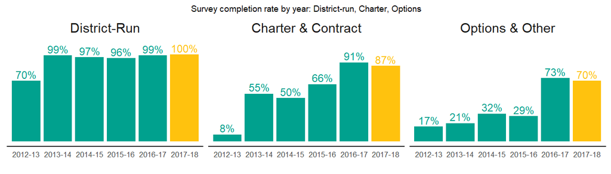

#### III-A: Creative Schools Certifications

Jump back to top

**Takeaways:**

- Small drop in Excelling schools (40% vs. 43% in 2016-17).
- High schools are improving, drop comes in from elementary schools.
- Bigger drop in charter/contract than district-run CSCs.

Table 6: Creative Schools Certifications, district overall

| FinalScore | Num 2012-13 | Total 2012-13 | Percent 2012-13 | Num 2013-14 | Total 2013-14 | Percent 2013-14 | Num 2014-15 | Total 2014-15 | Percent 2014-15 | Num 2015-16 | Total 2015-16 | Percent 2015-16 | Num 2016-17 | Total 2016-17 | Percent 2016-17 | Num 2017-18 | Total 2017-18 | Percent 2017-18 |
| --- | --- | --- | --- | --- | --- | --- | --- | --- | --- | --- | --- | --- | --- | --- | --- | --- | --- | --- |
| 1 | 84 | 681 | 12% | 185 | 664 | 28% | 231 | 664 | 35% | 258 | 660 | 39% | 283 | 653 | 43% | 261 | 650 | 40% |
| 2 | 112 | 681 | 16% | 147 | 664 | 22% | 146 | 664 | 22% | 138 | 660 | 21% | 151 | 653 | 23% | 147 | 650 | 23% |
| 3 | 147 | 681 | 22% | 172 | 664 | 26% | 139 | 664 | 21% | 143 | 660 | 22% | 129 | 653 | 20% | 128 | 650 | 20% |
| 4 | 44 | 681 | 6% | 81 | 664 | 12% | 55 | 664 | 8% | 41 | 660 | 6% | 68 | 653 | 10% | 91 | 650 | 14% |
| 5 | 294 | 681 | 43% | 79 | 664 | 12% | 93 | 664 | 14% | 80 | 660 | 12% | 22 | 653 | 3% | 23 | 650 | 4% |

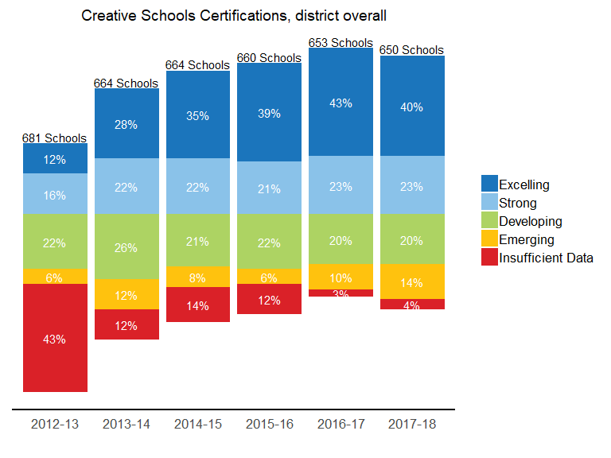

Table 7: Creative Schools Certifications, elementary schools

| FinalScore | Num 2012-13 | Total 2012-13 | Percent 2012-13 | Num 2013-14 | Total 2013-14 | Percent 2013-14 | Num 2014-15 | Total 2014-15 | Percent 2014-15 | Num 2015-16 | Total 2015-16 | Percent 2015-16 | Num 2016-17 | Total 2016-17 | Percent 2016-17 | Num 2017-18 | Total 2017-18 | Percent 2017-18 |
| --- | --- | --- | --- | --- | --- | --- | --- | --- | --- | --- | --- | --- | --- | --- | --- | --- | --- | --- |
| 1 | 80 | 527 | 15% | 155 | 485 | 32% | 197 | 483 | 41% | 224 | 484 | 46% | 233 | 481 | 48% | 211 | 480 | 44% |
| 2 | 89 | 527 | 17% | 129 | 485 | 27% | 129 | 483 | 27% | 109 | 484 | 23% | 115 | 481 | 24% | 102 | 480 | 21% |
| 3 | 113 | 527 | 21% | 123 | 485 | 25% | 91 | 483 | 19% | 90 | 484 | 19% | 86 | 481 | 18% | 100 | 480 | 21% |
| 4 | 34 | 527 | 6% | 54 | 485 | 11% | 26 | 483 | 5% | 28 | 484 | 6% | 44 | 481 | 9% | 64 | 480 | 13% |
| 5 | 211 | 527 | 40% | 24 | 485 | 5% | 40 | 483 | 8% | 33 | 484 | 7% | 3 | 481 | 1% | 3 | 480 | 1% |

Table 8: Creative Schools Certifications, high schools

| FinalScore | Num 2012-13 | Total 2012-13 | Percent 2012-13 | Num 2013-14 | Total 2013-14 | Percent 2013-14 | Num 2014-15 | Total 2014-15 | Percent 2014-15 | Num 2015-16 | Total 2015-16 | Percent 2015-16 | Num 2016-17 | Total 2016-17 | Percent 2016-17 | Num 2017-18 | Total 2017-18 | Percent 2017-18 |
| --- | --- | --- | --- | --- | --- | --- | --- | --- | --- | --- | --- | --- | --- | --- | --- | --- | --- | --- |
| 1 | 4 | 154 | 3% | 30 | 179 | 17% | 34 | 181 | 19% | 34 | 176 | 19% | 50 | 172 | 29% | 50 | 170 | 29% |
| 2 | 23 | 154 | 15% | 18 | 179 | 10% | 17 | 181 | 9% | 29 | 176 | 16% | 36 | 172 | 21% | 45 | 170 | 26% |
| 3 | 34 | 154 | 22% | 49 | 179 | 27% | 48 | 181 | 27% | 53 | 176 | 30% | 43 | 172 | 25% | 28 | 170 | 16% |
| 4 | 10 | 154 | 6% | 27 | 179 | 15% | 29 | 181 | 16% | 13 | 176 | 7% | 24 | 172 | 14% | 27 | 170 | 16% |
| 5 | 83 | 154 | 54% | 55 | 179 | 31% | 53 | 181 | 29% | 47 | 176 | 27% | 19 | 172 | 11% | 20 | 170 | 12% |

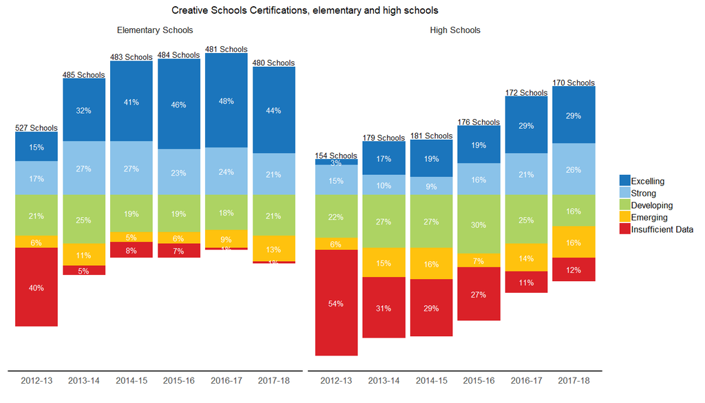

Table 9: Creative Schools Certifications, district-run schools

| FinalScore | Num 2012-13 | Total 2012-13 | Percent 2012-13 | Num 2013-14 | Total 2013-14 | Percent 2013-14 | Num 2014-15 | Total 2014-15 | Percent 2014-15 | Num 2015-16 | Total 2015-16 | Percent 2015-16 | Num 2016-17 | Total 2016-17 | Percent 2016-17 | Num 2017-18 | Total 2017-18 | Percent 2017-18 |
| --- | --- | --- | --- | --- | --- | --- | --- | --- | --- | --- | --- | --- | --- | --- | --- | --- | --- | --- |
| 1 | 80 | 523 | 15% | 176 | 526 | 33% | 213 | 520 | 41% | 234 | 517 | 45% | 248 | 518 | 48% | 229 | 518 | 44% |
| 2 | 108 | 523 | 21% | 138 | 526 | 26% | 132 | 520 | 25% | 114 | 517 | 22% | 117 | 518 | 23% | 122 | 518 | 24% |
| 3 | 139 | 523 | 27% | 144 | 526 | 27% | 122 | 520 | 23% | 125 | 517 | 24% | 105 | 518 | 20% | 107 | 518 | 21% |
| 4 | 39 | 523 | 7% | 61 | 526 | 12% | 37 | 520 | 7% | 24 | 517 | 5% | 43 | 518 | 8% | 59 | 518 | 11% |
| 5 | 157 | 523 | 30% | 7 | 526 | 1% | 16 | 520 | 3% | 20 | 517 | 4% | 5 | 518 | 1% | 1 | 518 | 0% |

Table 10: Creative Schools Certifications, charter and contract schools

| FinalScore | Num 2012-13 | Total 2012-13 | Percent 2012-13 | Num 2013-14 | Total 2013-14 | Percent 2013-14 | Num 2014-15 | Total 2014-15 | Percent 2014-15 | Num 2015-16 | Total 2015-16 | Percent 2015-16 | Num 2016-17 | Total 2016-17 | Percent 2016-17 | Num 2017-18 | Total 2017-18 | Percent 2017-18 |
| --- | --- | --- | --- | --- | --- | --- | --- | --- | --- | --- | --- | --- | --- | --- | --- | --- | --- | --- |
| 1 | 2 | 97 | 2% | 8 | 107 | 7% | 18 | 113 | 16% | 22 | 112 | 20% | 31 | 105 | 30% | 29 | 105 | 28% |
| 2 | 2 | 97 | 2% | 8 | 107 | 7% | 12 | 113 | 11% | 22 | 112 | 20% | 29 | 105 | 28% | 19 | 105 | 18% |
| 3 | 3 | 97 | 3% | 25 | 107 | 23% | 14 | 113 | 12% | 14 | 112 | 12% | 21 | 105 | 20% | 21 | 105 | 20% |
| 4 | 1 | 97 | 1% | 18 | 107 | 17% | 13 | 113 | 12% | 16 | 112 | 14% | 15 | 105 | 14% | 22 | 105 | 21% |
| 5 | 89 | 97 | 92% | 48 | 107 | 45% | 56 | 113 | 50% | 38 | 112 | 34% | 9 | 105 | 9% | 14 | 105 | 13% |

Table 11: Creative Schools Certifications, other school types

| FinalScore | Num 2012-13 | Total 2012-13 | Percent 2012-13 | Num 2013-14 | Total 2013-14 | Percent 2013-14 | Num 2014-15 | Total 2014-15 | Percent 2014-15 | Num 2015-16 | Total 2015-16 | Percent 2015-16 | Num 2016-17 | Total 2016-17 | Percent 2016-17 | Num 2017-18 | Total 2017-18 | Percent 2017-18 |
| --- | --- | --- | --- | --- | --- | --- | --- | --- | --- | --- | --- | --- | --- | --- | --- | --- | --- | --- |
| 1 | NA | NA | NA | NA | NA | NA | NA | NA | NA | 2 | 31 | 6% | 4 | 30 | 13% | 3 | 27 | 11% |
| 2 | NA | NA | NA | 1 | 29 | 3% | 2 | 31 | 6% | 2 | 31 | 6% | 5 | 30 | 17% | 6 | 27 | 22% |
| 3 | NA | NA | NA | 3 | 29 | 10% | 3 | 31 | 10% | 4 | 31 | 13% | 3 | 30 | 10% | NA | NA | NA |
| 4 | 1 | 6 | 17% | 2 | 29 | 7% | 5 | 31 | 16% | 1 | 31 | 3% | 10 | 30 | 33% | 10 | 27 | 37% |
| 5 | 5 | 6 | 83% | 23 | 29 | 79% | 21 | 31 | 68% | 22 | 31 | 71% | 8 | 30 | 27% | 8 | 27 | 30% |

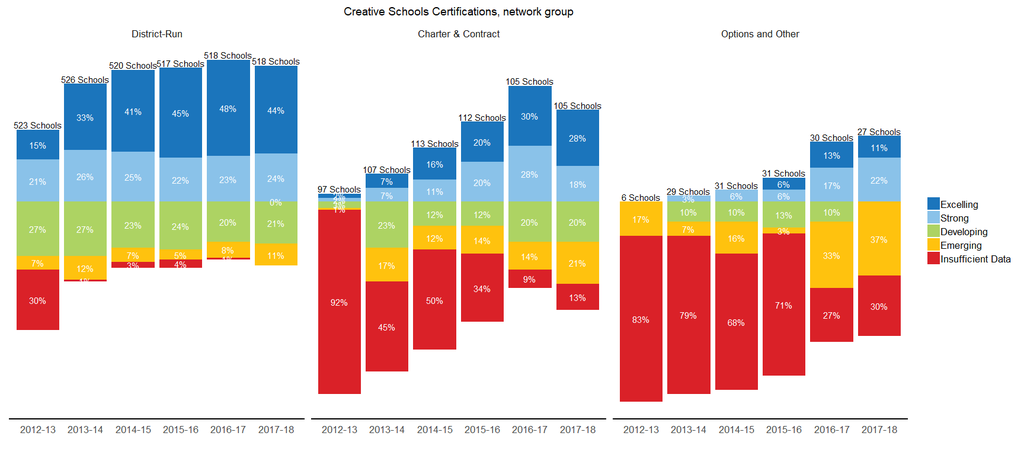

#### III-B: Staffing

Jump back to top

**Takeaways:**

- Small drop in FTEs from previous year.
- Elementary schools commonly have 1 - 2.5 FTE.High schools have a bigger range; one-third of HS have 4 or more FTE. This pattern is stable over time.
- Visual arts, music continue to be most common staffing categories.
- 0 FTE are slightly on the rise in elementary schools, options schools.
- Overall the district has met the 1:350 staffing ratio, but not all schools have. HS are closest (88%), options are weakest (63%) on this metric.

In order to meet the 1:350 staffing ratio district-wide, CPS would have to employ 351,941 / 350 = **1006** arts instructors.

Table 13: FTE Count, district overall

| School Year | Number of FTEs |
| --- | --- |
| 2012-13 | 1163.400 |
| 2013-14 | 1288.000 |
| 2014-15 | 1346.500 |
| 2015-16 | 1403.485 |
| 2016-17 | 1490.100 |
| 2017-18 | 1462.200 |

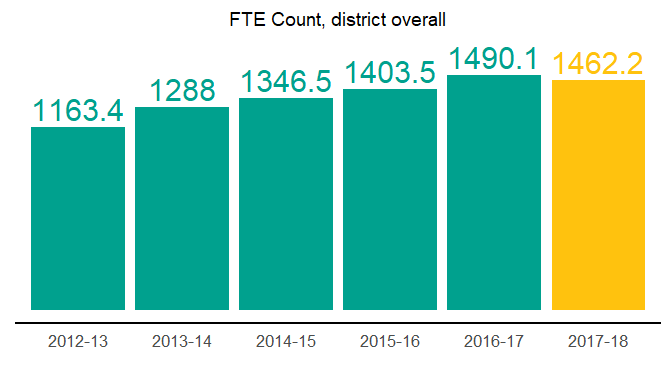

Note: Data sources for this table include the Creative Schools Survey and CPS staffing files. This table, therefore, captures arts staff that existed in any of CPS’ “school units” for a given year (i.e., 666 for 2017-18). Considering data from both reporting and non-reporting schools provides a more complete picture of arts staffing across the district. Due to a lower response rate on the CSS in its first year, satffing totals for 2012-13 are based only on data from CPS Office of Accountability arts staffing files as of June 15, 2013.

| SchoolYears | SchoolType | Category | Num | N | Percent |
| --- | --- | --- | --- | --- | --- |
| 2017-18 | ES | 4 or more | 31 | 477 | 6% |
| 2017-18 | ES | 3 - 3.5 | 68 | 477 | 14% |
| 2017-18 | ES | 2 - 2.5 | 150 | 477 | 31% |
| 2017-18 | ES | 1 - 1.5 | 169 | 477 | 35% |
| 2017-18 | ES | 0.5 | 16 | 477 | 3% |
| 2017-18 | ES | 0 | 43 | 477 | 9% |
| 2017-18 | HS | 4 or more | 50 | 150 | 33% |
| 2017-18 | HS | 3 - 3.5 | 22 | 150 | 15% |
| 2017-18 | HS | 2 - 2.5 | 38 | 150 | 25% |
| 2017-18 | HS | 1 - 1.5 | 30 | 150 | 20% |

[output cut: 59 more lines]

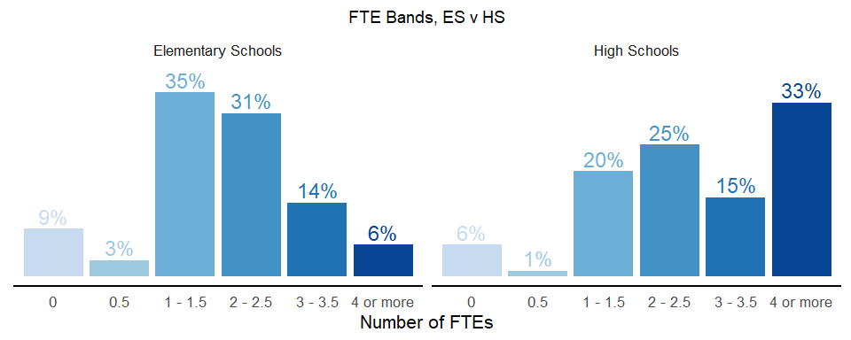

Note: These data are calculated from the “condensed” rubrics (i.e., 650 schools for SY 2017-18) and only includes those schools that completed a Creative Schools Survey

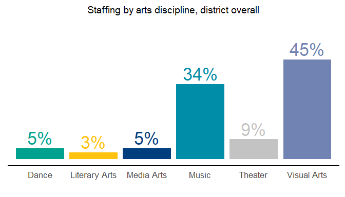

Note: Data sources for this table include the Creative Schools Survey and CPS staffing files. This table, therefore, captures arts staff that existed in any of CPS’ “school units” for a given year (i.e., 666 for 2017-18). Considering data from both reporting and non-reporting schools provides a more complete picture of arts staffing across the district.

| SchoolYears | SchoolType | ArtsDiscipline | FTEsByDiscipline | TotalFTEs | Percent |
| --- | --- | --- | --- | --- | --- |
| 2017-18 | ES | Dance | 33.5 | 793 | 4.2% |
| 2017-18 | ES | LiteraryArts | 9 | 793 | 1.1% |
| 2017-18 | ES | MediaArts | 34.5 | 793 | 4.4% |
| 2017-18 | ES | Music | 285.5 | 793 | 36% |
| 2017-18 | ES | Theater | 49 | 793 | 6.2% |
| 2017-18 | ES | VisualArts | 381.5 | 793 | 48.1% |
| 2017-18 | HS | Dance | 30.5 | 607.6 | 5% |
| 2017-18 | HS | LiteraryArts | 38.5 | 607.6 | 6.3% |
| 2017-18 | HS | MediaArts | 30 | 607.6 | 4.9% |
| 2017-18 | HS | Music | 188.8 | 607.6 | 31.1% |

[output cut: 48 more lines]

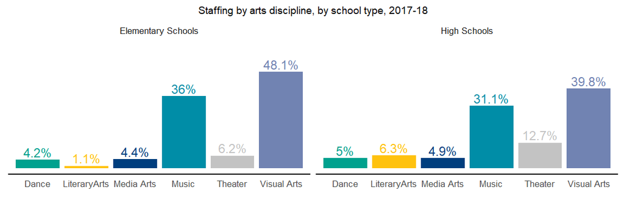

Note: Data sources for this table include the Creative Schools Survey and CPS staffing files. This table, therefore, captures arts staff that existed in any of CPS’ “school units” for a given year (i.e., 666 for 2017-18). Considering data from both reporting and non-reporting schools provides a more complete picture of arts staffing across the district.

Table 17: Staffing categories, district overall

| Staff Score | Num 2012-13 | Total 2012-13 | Percent 2012-13 | Num 2013-14 | Total 2013-14 | Percent 2013-14 | Num 2014-15 | Total 2014-15 | Percent 2014-15 | Num 2015-16 | Total 2015-16 | Percent 2015-16 | Num 2016-17 | Total 2016-17 | Percent 2016-17 | Num 2017-18 | Total 2017-18 | Percent 2017-18 |
| --- | --- | --- | --- | --- | --- | --- | --- | --- | --- | --- | --- | --- | --- | --- | --- | --- | --- | --- |
| 1 | 199 | 387 | 51% | 342 | 585 | 58% | 387 | 571 | 68% | 421 | 580 | 73% | 446 | 631 | 71% | 431 | 627 | 69% |
| 2 | 145 | 387 | 37% | 172 | 585 | 29% | 133 | 571 | 23% | 121 | 580 | 21% | 131 | 631 | 21% | 130 | 627 | 21% |
| 3 | 31 | 387 | 8% | 33 | 585 | 6% | 28 | 571 | 5% | 21 | 580 | 4% | 16 | 631 | 3% | 14 | 627 | 2% |
| 4 | 12 | 387 | 3% | 38 | 585 | 6% | 23 | 571 | 4% | 17 | 580 | 3% | 38 | 631 | 6% | 52 | 627 | 8% |

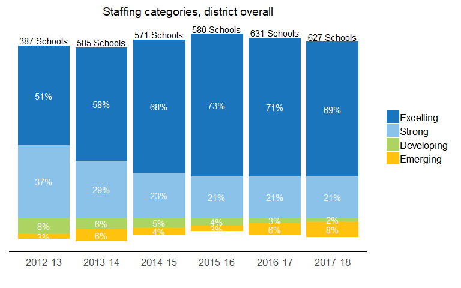

Note: These data are calculated from the “condensed” rubrics (i.e., 650 schools for SY 2017-18) and only includes those schools that completed a Creative Schools Survey

Note: These data are calculated from the “condensed” rubrics (i.e., 6650 schools for SY 2017-18) and only includes those schools that completed a Creative Schools Survey. This is why, for example, the table lists 478 elementary schools for SY 2016-17.

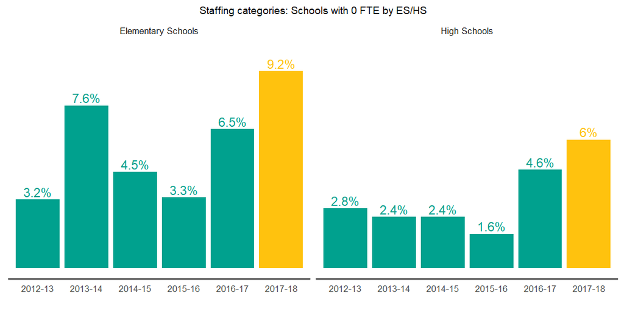

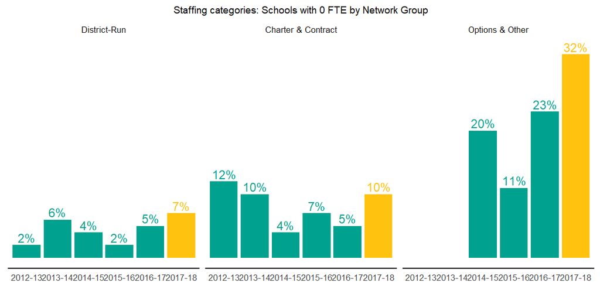

Note: These data are calculated from the “condensed” rubrics (i.e., 650 schools for SY 2017-18) and only includes those schools that completed a Creative Schools Survey. This is why, for example, the table lists 153 high schools for SY 2016-17.

Table 20: Staffing ratios, district overall

| Ratio | Num 2012-13 | Total 2012-13 | Percent 2012-13 | Num 2013-14 | Total 2013-14 | Percent 2013-14 | Num 2014-15 | Total 2014-15 | Percent 2014-15 | Num 2015-16 | Total 2015-16 | Percent 2015-16 | Num 2016-17 | Total 2016-17 | Percent 2016-17 | Num 2017-18 | Total 2017-18 | Percent 2017-18 |
| --- | --- | --- | --- | --- | --- | --- | --- | --- | --- | --- | --- | --- | --- | --- | --- | --- | --- | --- |
| 1:350 or better | 199 | 387 | 51 % | 342 | 585 | 58 % | 387 | 570 | 68 % | 421 | 580 | 73 % | 446 | 631 | 71 % | 425 | 627 | 68 % |
| 1:351 - 1:500 | 78 | 387 | 20 % | 109 | 585 | 19 % | 111 | 570 | 19 % | 89 | 580 | 15 % | 88 | 631 | 14 % | 100 | 627 | 16 % |
| 1:501 - 1:750 | 64 | 387 | 17 % | 75 | 585 | 13 % | 36 | 570 | 6 % | 45 | 580 | 8 % | 51 | 631 | 8 % | 38 | 627 | 6 % |
| Greater than 750 | 34 | 387 | 9 % | 21 | 585 | 4 % | 13 | 570 | 2 % | 8 | 580 | 1 % | 8 | 631 | 1 % | 11 | 627 | 2 % |
| No FTE | 12 | 387 | 3 % | 38 | 585 | 6 % | 23 | 570 | 4 % | 17 | 580 | 3 % | 38 | 631 | 6 % | 53 | 627 | 8 % |

Note: These data are calculated from the “condensed” rubrics (i.e., 650 schools for SY 2017-18) and only include schools that completed the Creative Schools Survey.

Table 21: Staffing ratios, elementary schools

| Ratio | Num 2012-13 | Total 2012-13 | Percent 2012-13 | Num 2013-14 | Total 2013-14 | Percent 2013-14 | Num 2014-15 | Total 2014-15 | Percent 2014-15 | Num 2015-16 | Total 2015-16 | Percent 2015-16 | Num 2016-17 | Total 2016-17 | Percent 2016-17 | Num 2017-18 | Total 2017-18 | Percent 2017-18 |
| --- | --- | --- | --- | --- | --- | --- | --- | --- | --- | --- | --- | --- | --- | --- | --- | --- | --- | --- |
| 1:350 or better | 134 | 316 | 42.4% | 232 | 461 | 50.3% | 274 | 443 | 61.9% | 308 | 451 | 68.3% | 308 | 478 | 64.4% | 293 | 477 | 61.4% |
| 1:351 - 1:500 | 76 | 316 | 24.1% | 103 | 461 | 22.3% | 104 | 443 | 23.5% | 78 | 451 | 17.3% | 83 | 478 | 17.4% | 95 | 477 | 19.9% |
| 1:501 - 1:750 | 63 | 316 | 19.9% | 71 | 461 | 15.4% | 32 | 443 | 7.2% | 42 | 451 | 9.3% | 50 | 478 | 10.5% | 37 | 477 | 7.8% |
| Greater than 750 | 33 | 316 | 10.4% | 20 | 461 | 4.3% | 13 | 443 | 2.9% | 8 | 451 | 1.8% | 6 | 478 | 1.3% | 8 | 477 | 1.7% |
| No FTE | 10 | 316 | 3.2% | 35 | 461 | 7.6% | 20 | 443 | 4.5% | 15 | 451 | 3.3% | 31 | 478 | 6.5% | 44 | 477 | 9.2% |

Table 22: Staffing ratios, high schools

| Ratio | Num 2012-13 | Total 2012-13 | Percent 2012-13 | Num 2013-14 | Total 2013-14 | Percent 2013-14 | Num 2014-15 | Total 2014-15 | Percent 2014-15 | Num 2015-16 | Total 2015-16 | Percent 2015-16 | Num 2016-17 | Total 2016-17 | Percent 2016-17 | Num 2017-18 | Total 2017-18 | Percent 2017-18 |
| --- | --- | --- | --- | --- | --- | --- | --- | --- | --- | --- | --- | --- | --- | --- | --- | --- | --- | --- |
| 1:350 or better | 65 | 71 | 91.5% | 110 | 124 | 88.7% | 113 | 127 | 89% | 113 | 129 | 87.6% | 138 | 153 | 90.2% | 132 | 150 | 88% |
| 1:351 - 1:500 | 2 | 71 | 2.8% | 6 | 124 | 4.8% | 7 | 127 | 5.5% | 11 | 129 | 8.5% | 5 | 153 | 3.3% | 5 | 150 | 3.3% |
| 1:501 - 1:750 | 1 | 71 | 1.4% | 4 | 124 | 3.2% | 4 | 127 | 3.1% | 3 | 129 | 2.3% | 1 | 153 | 0.7% | 1 | 150 | 0.7% |
| Greater than 750 | 1 | 71 | 1.4% | 1 | 124 | 0.8% | NA | NA | NA | NA | NA | NA | 2 | 153 | 1.3% | 3 | 150 | 2% |
| No FTE | 2 | 71 | 2.8% | 3 | 124 | 2.4% | 3 | 127 | 2.4% | 2 | 129 | 1.6% | 7 | 153 | 4.6% | 9 | 150 | 6% |

Table 23: Staffing ratios, district-run schools

| Ratio | Num 2012-13 | Total 2012-13 | Percent 2012-13 | Num 2013-14 | Total 2013-14 | Percent 2013-14 | Num 2014-15 | Total 2014-15 | Percent 2014-15 | Num 2015-16 | Total 2015-16 | Percent 2015-16 | Num 2016-17 | Total 2016-17 | Percent 2016-17 | Num 2017-18 | Total 2017-18 | Percent 2017-18 |
| --- | --- | --- | --- | --- | --- | --- | --- | --- | --- | --- | --- | --- | --- | --- | --- | --- | --- | --- |
| 1:350 or better | 184 | 366 | 50% | 299 | 519 | 58% | 337 | 503 | 67% | 362 | 497 | 73% | 360 | 513 | 70% | 349 | 517 | 68% |
| 1:351 - 1:500 | 75 | 366 | 20% | 103 | 519 | 20% | 101 | 503 | 20% | 81 | 497 | 16% | 75 | 513 | 15% | 88 | 517 | 17% |
| 1:501 - 1:750 | 64 | 366 | 17% | 65 | 519 | 13% | 33 | 503 | 7% | 37 | 497 | 7% | 45 | 513 | 9% | 34 | 517 | 7% |
| Greater than 750 | 34 | 366 | 9% | 20 | 519 | 4% | 13 | 503 | 3% | 6 | 497 | 1% | 5 | 513 | 1% | 8 | 517 | 2% |
| No FTE | 9 | 366 | 2% | 32 | 519 | 6% | 19 | 503 | 4% | 11 | 497 | 2% | 28 | 513 | 5% | 38 | 517 | 7% |

Note: These data are calculated from the “condensed” rubrics (i.e., 650 schools for SY 2017-18) and only include schools that completed the Creative Schools Survey.

Table 24: Staffing ratios, charter and contract schools

| Ratio | Num 2012-13 | Total 2012-13 | Percent 2012-13 | Num 2013-14 | Total 2013-14 | Percent 2013-14 | Num 2014-15 | Total 2014-15 | Percent 2014-15 | Num 2015-16 | Total 2015-16 | Percent 2015-16 | Num 2016-17 | Total 2016-17 | Percent 2016-17 | Num 2017-18 | Total 2017-18 | Percent 2017-18 |
| --- | --- | --- | --- | --- | --- | --- | --- | --- | --- | --- | --- | --- | --- | --- | --- | --- | --- | --- |
| 1:350 or better | 7 | 8 | 88% | 36 | 59 | 61% | 42 | 57 | 74% | 51 | 74 | 69% | 69 | 96 | 72% | 64 | 91 | 70% |
| 1:351 - 1:500 | NA | NA | NA | 6 | 59 | 10% | 10 | 57 | 18% | 8 | 74 | 11% | 13 | 96 | 14% | 11 | 91 | 12% |
| 1:501 - 1:750 | NA | NA | NA | 10 | 59 | 17% | 3 | 57 | 5% | 8 | 74 | 11% | 6 | 96 | 6% | 4 | 91 | 4% |
| Greater than 750 | NA | NA | NA | 1 | 59 | 2% | NA | NA | NA | 2 | 74 | 3% | 3 | 96 | 3% | 3 | 91 | 3% |
| No FTE | 1 | 8 | 12% | 6 | 59 | 10% | 2 | 57 | 4% | 5 | 74 | 7% | 5 | 96 | 5% | 9 | 91 | 10% |

Note: These data are calculated from the “condensed” rubrics (i.e., 650 schools for SY 2017-18) and only include schools that completed the Creative Schools Survey.

Table 25: Staffing ratios, other school types

| Ratio | Num 2012-13 | Total 2012-13 | Percent 2012-13 | Num 2013-14 | Total 2013-14 | Percent 2013-14 | Num 2014-15 | Total 2014-15 | Percent 2014-15 | Num 2015-16 | Total 2015-16 | Percent 2015-16 | Num 2016-17 | Total 2016-17 | Percent 2016-17 | Num 2017-18 | Total 2017-18 | Percent 2017-18 |
| --- | --- | --- | --- | --- | --- | --- | --- | --- | --- | --- | --- | --- | --- | --- | --- | --- | --- | --- |
| 1:350 or better | 1 | 1 | 100% | 6 | 6 | 100% | 8 | 10 | 80% | 8 | 9 | 89% | 17 | 22 | 77% | 12 | 19 | 63% |
| 1:351 - 1:500 | NA | NA | NA | NA | NA | NA | NA | NA | NA | NA | NA | NA | NA | NA | NA | 1 | 19 | 5% |
| No FTE | NA | NA | NA | NA | NA | NA | 2 | 10 | 20% | 1 | 9 | 11% | 5 | 22 | 23% | 6 | 19 | 32% |

Note: These data are calculated from the “condensed” rubrics (i.e., 650 schools for SY 2017-18) and only include schools that completed the Creative Schools Survey.

#### III-C: Minutes of Instruction, Elementary Schools

Jump back to top

**Takeaways:**

- Drop in strong/excelling scores in minutes of instruction this year.
- Drop seen in both district-run and charter/contract schools.

Table 27: Minutes of Instruction, district overall

| Minutes | Num 2012-13 | Total 2012-13 | Percent 2012-13 | Num 2013-14 | Total 2013-14 | Percent 2013-14 | Num 2014-15 | Total 2014-15 | Percent 2014-15 | Num 2015-16 | Total 2015-16 | Percent 2015-16 | Num 2016-17 | Total 2016-17 | Percent 2016-17 | Num 2017-18 | Total 2017-18 | Percent 2017-18 |
| --- | --- | --- | --- | --- | --- | --- | --- | --- | --- | --- | --- | --- | --- | --- | --- | --- | --- | --- |
| 1 | 131 | 316 | 41% | 215 | 461 | 47% | 262 | 443 | 59% | 264 | 451 | 59% | 287 | 478 | 60% | 259 | 477 | 54% |
| 2 | 52 | 316 | 16% | 87 | 461 | 19% | 85 | 443 | 19% | 79 | 451 | 18% | 76 | 478 | 16% | 77 | 477 | 16% |
| 3 | 113 | 316 | 36% | 113 | 461 | 25% | 89 | 443 | 20% | 86 | 451 | 19% | 79 | 478 | 17% | 90 | 477 | 19% |
| 4 | 20 | 316 | 6% | 46 | 461 | 10% | 7 | 443 | 2% | 22 | 451 | 5% | 36 | 478 | 8% | 51 | 477 | 11% |

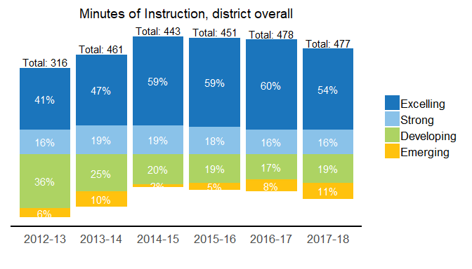

Note: These data are calculated from the “condensed” rubrics (i.e., 650 schools for SY 2017-18) and only include those schools that responded to the survey.

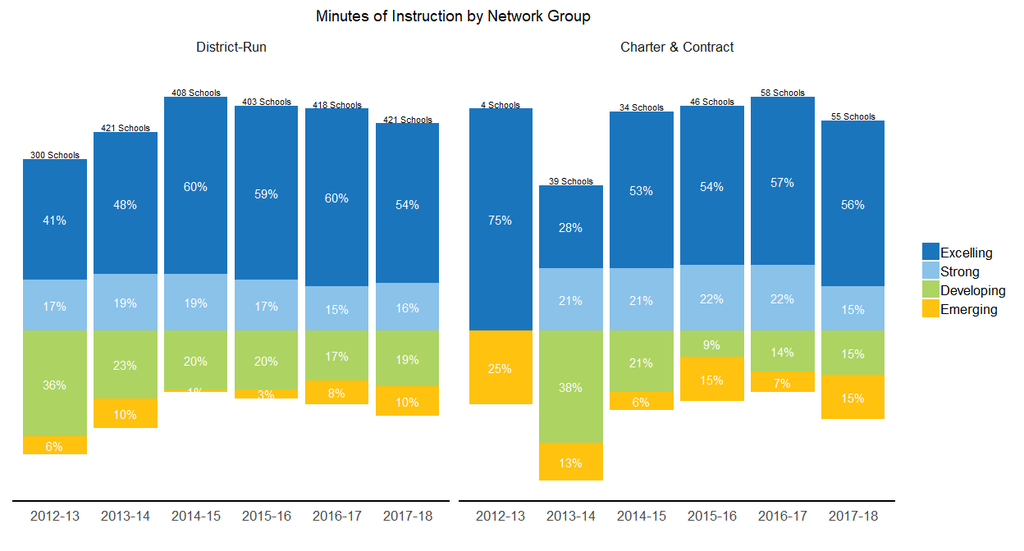

Note: These data are calculated from the “condensed” rubrics (i.e., 650 schools for SY 2017-18) and only include those schools that responded to the survey.

#### III-D: Percent Access, Elementary Schools

Jump back to top

**Takeaways:**

- Access across grades is also on a downward trend.
- 7% fewer schools achieving Excelling this year.

Table 29: Percent Access

| Access | Num 2012-13 | Total 2012-13 | Percent 2012-13 | Num 2013-14 | Total 2013-14 | Percent 2013-14 | Num 2014-15 | Total 2014-15 | Percent 2014-15 | Num 2015-16 | Total 2015-16 | Percent 2015-16 | Num 2016-17 | Total 2016-17 | Percent 2016-17 | Num 2017-18 | Total 2017-18 | Percent 2017-18 |
| --- | --- | --- | --- | --- | --- | --- | --- | --- | --- | --- | --- | --- | --- | --- | --- | --- | --- | --- |
| 1 | 287 | 316 | 91% | 358 | 461 | 78% | 387 | 443 | 87% | 389 | 451 | 86% | 406 | 478 | 85% | 373 | 477 | 78% |
| 2 | 20 | 316 | 6% | 36 | 461 | 8% | 37 | 443 | 8% | 25 | 451 | 6% | 23 | 478 | 5% | 31 | 477 | 6% |
| 3 | 4 | 316 | 1% | 23 | 461 | 5% | 11 | 443 | 2% | 12 | 451 | 3% | 13 | 478 | 3% | 15 | 477 | 3% |
| 4 | 5 | 316 | 2% | 44 | 461 | 10% | 8 | 443 | 2% | 25 | 451 | 6% | 36 | 478 | 8% | 58 | 477 | 12% |

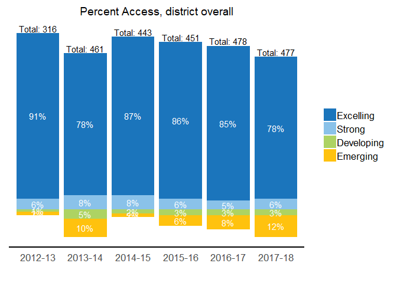

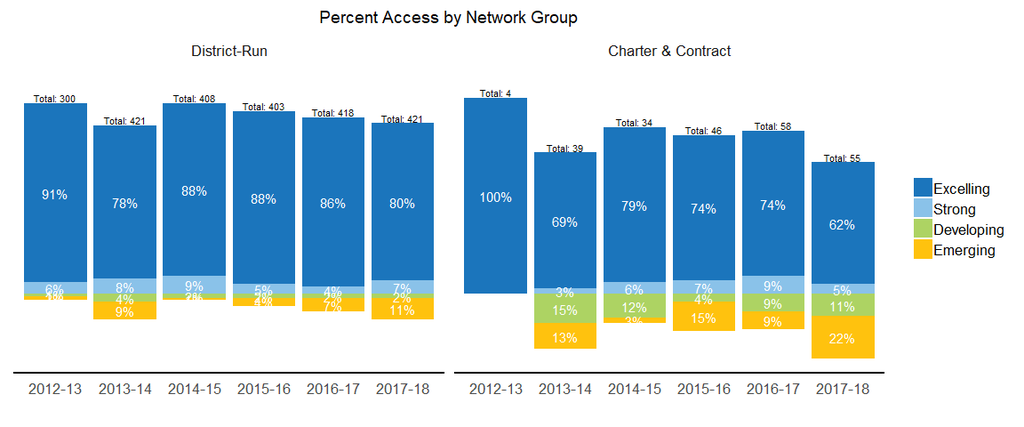

Note: These data are calculated from the “condensed” rubrics (i.e., 650 schools for SY 2017-18) and only include those schools that responded to the survey.

#### III-E: Disciplines & Depth, High Schools

Jump back to top

**Takeaways:**

- Disciplines & Depth upswing: 5% more schools receiving a Strong rating than 2016-17.
- Improvement driven largely by district-run schools.

Table 30: HS Disciplines and Depth, district overall

| Disciplines | Num 2012-13 | Total 2012-13 | Percent 2012-13 | Num 2013-14 | Total 2013-14 | Percent 2013-14 | Num 2014-15 | Total 2014-15 | Percent 2014-15 | Num 2015-16 | Total 2015-16 | Percent 2015-16 | Num 2016-17 | Total 2016-17 | Percent 2016-17 | Num 2017-18 | Total 2017-18 | Percent 2017-18 |
| --- | --- | --- | --- | --- | --- | --- | --- | --- | --- | --- | --- | --- | --- | --- | --- | --- | --- | --- |
| 1 | 17 | 69 | 25% | 30 | 123 | 24% | 34 | 128 | 27% | 34 | 129 | 26% | 50 | 153 | 33% | 50 | 150 | 33% |
| 2 | 10 | 69 | 14% | 17 | 123 | 14% | 17 | 128 | 13% | 30 | 129 | 23% | 38 | 153 | 25% | 45 | 150 | 30% |
| 3 | 34 | 69 | 49% | 52 | 123 | 42% | 51 | 128 | 40% | 53 | 129 | 41% | 45 | 153 | 29% | 30 | 150 | 20% |
| 4 | 8 | 69 | 12% | 24 | 123 | 20% | 26 | 128 | 20% | 12 | 129 | 9% | 20 | 153 | 13% | 25 | 150 | 17% |

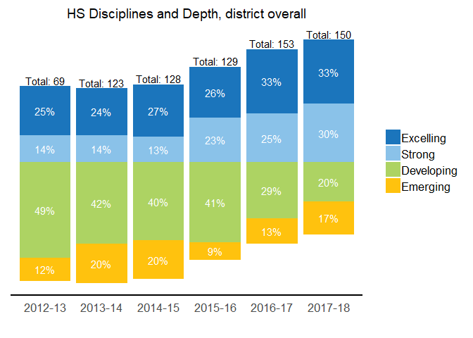

Note: These data are calculated from the “condensed” rubrics (i.e., 650 schools for SY 2017-18) and only include those schools that responded to the survey.

Table 31: HS Disciplines and Depth, district-run

| Disciplines | Num 2012-13 | Total 2012-13 | Percent 2012-13 | Num 2013-14 | Total 2013-14 | Percent 2013-14 | Num 2014-15 | Total 2014-15 | Percent 2014-15 | Num 2015-16 | Total 2015-16 | Percent 2015-16 | Num 2016-17 | Total 2016-17 | Percent 2016-17 | Num 2017-18 | Total 2017-18 | Percent 2017-18 |
| --- | --- | --- | --- | --- | --- | --- | --- | --- | --- | --- | --- | --- | --- | --- | --- | --- | --- | --- |
| 1 | 16 | 65 | 25% | 28 | 97 | 29% | 30 | 96 | 31% | 29 | 94 | 31% | 39 | 95 | 41% | 39 | 96 | 41% |
| 2 | 10 | 65 | 15% | 15 | 97 | 15% | 11 | 96 | 11% | 21 | 94 | 22% | 20 | 95 | 21% | 29 | 96 | 30% |
| 3 | 31 | 65 | 48% | 43 | 97 | 44% | 41 | 96 | 43% | 38 | 94 | 40% | 30 | 95 | 32% | 20 | 96 | 21% |
| 4 | 8 | 65 | 12% | 11 | 97 | 11% | 14 | 96 | 15% | 6 | 94 | 6% | 6 | 95 | 6% | 8 | 96 | 8% |

Note: These data are calculated from the “condensed” rubrics (i.e., 650 schools for SY 2017-18) and only include those schools that responded to the survey.

Table 32: HS Disciplines and Depth, charter and contract schools

| Disciplines | Num 2012-13 | Total 2012-13 | Percent 2012-13 | Num 2013-14 | Total 2013-14 | Percent 2013-14 | Num 2014-15 | Total 2014-15 | Percent 2014-15 | Num 2015-16 | Total 2015-16 | Percent 2015-16 | Num 2016-17 | Total 2016-17 | Percent 2016-17 | Num 2017-18 | Total 2017-18 | Percent 2017-18 |
| --- | --- | --- | --- | --- | --- | --- | --- | --- | --- | --- | --- | --- | --- | --- | --- | --- | --- | --- |
| 1 | 1 | 4 | 25% | 2 | 20 | 10% | 4 | 23 | 17% | 3 | 28 | 11% | 9 | 38 | 24% | 8 | 36 | 22% |
| 2 | NA | NA | NA | 1 | 20 | 5% | 4 | 23 | 17% | 8 | 28 | 29% | 12 | 38 | 32% | 11 | 36 | 31% |
| 3 | 3 | 4 | 75% | 6 | 20 | 30% | 6 | 23 | 26% | 11 | 28 | 39% | 13 | 38 | 34% | 10 | 36 | 28% |
| 4 | NA | NA | NA | 11 | 20 | 55% | 9 | 23 | 39% | 6 | 28 | 21% | 4 | 38 | 11% | 7 | 36 | 19% |

Note: These data are calculated from the “condensed” rubrics (i.e., 650 schools for SY 2017-18) and only include those schools that responded to the survey.

Table 33: HS Disciplines and Depth, options/other school types

| Disciplines | Num 2012-13 | Total 2012-13 | Percent 2012-13 | Num 2013-14 | Total 2013-14 | Percent 2013-14 | Num 2014-15 | Total 2014-15 | Percent 2014-15 | Num 2015-16 | Total 2015-16 | Percent 2015-16 | Num 2016-17 | Total 2016-17 | Percent 2016-17 | Num 2017-18 | Total 2017-18 | Percent 2017-18 |
| --- | --- | --- | --- | --- | --- | --- | --- | --- | --- | --- | --- | --- | --- | --- | --- | --- | --- | --- |
| 1 | NA | NA | NA | NA | NA | NA | NA | NA | NA | 2 | 7 | 29% | 2 | 20 | 10% | 3 | 18 | 17% |
| 2 | NA | NA | NA | 1 | 6 | 17% | 2 | 9 | 22% | 1 | 7 | 14% | 6 | 20 | 30% | 5 | 18 | 28% |
| 3 | NA | NA | NA | 3 | 6 | 50% | 4 | 9 | 44% | 4 | 7 | 57% | 2 | 20 | 10% | NA | NA | NA |
| 4 | NA | NA | NA | 2 | 6 | 33% | 3 | 9 | 33% | NA | NA | NA | 10 | 20 | 50% | 10 | 18 | 56% |

Note: These data are calculated from the “condensed” rubrics (i.e., 650 schools for SY 2017-18) and only include those schools that responded to the survey.

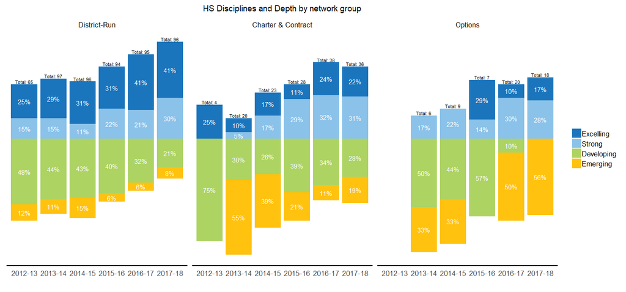

#### III-F: Additional Arts Assets

Jump back to top

**Takeaways:**

- Assets mostly stable across time.
- Some improvement/recovery in professional development, esp. in HS.
- Something of a downward trend in Budget over the years.

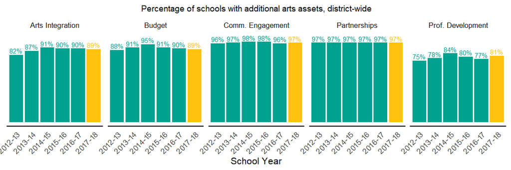

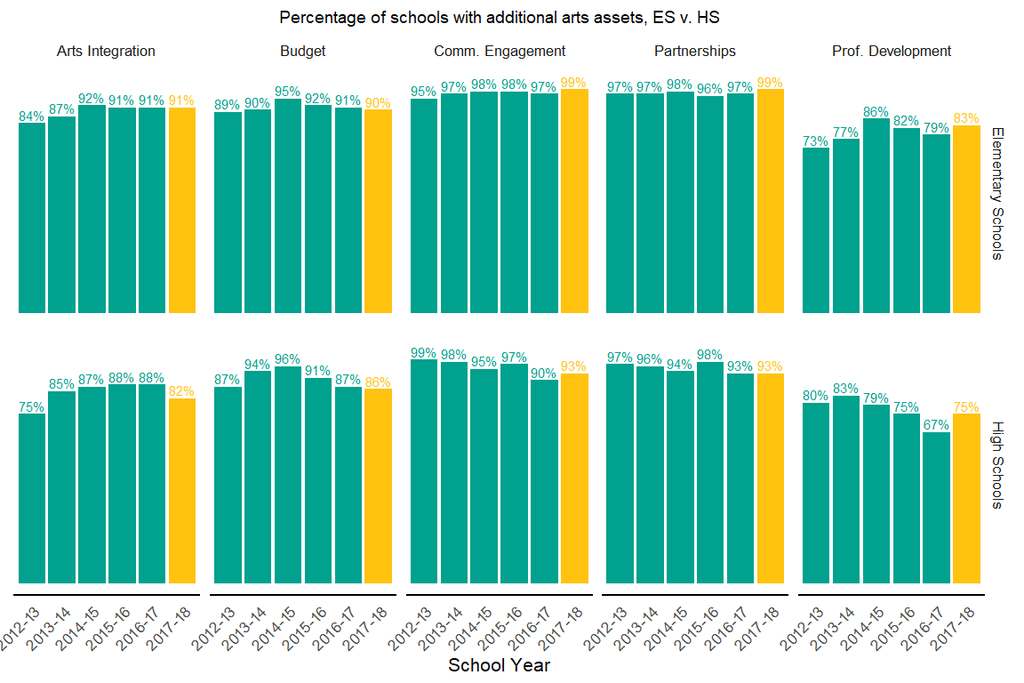

### Section IV: Partnerships

Jump back to top

#### IV-A: Partnership distribution

Jump back to top

**Takeaways:**

- Small bump in number of partners over last year.
- Small increase in average # of partners per school.
- Program types: Field trips, resources continue to grow; other categories (besides “other”) largely stable. Numbers to be updated slightly.
- Partner disciplines: music, visual arts most common; some growth in literary arts.

Table 49: Partner Count

| School Year | Number of Partners |
| --- | --- |
| 2012-13 | 435 |
| 2013-14 | 559 |
| 2014-15 | 559 |
| 2015-16 | 590 |
| 2016-17 | 526 |
| 2017-18 | 575 |

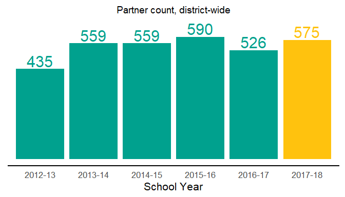

Table 50: Average Number of Arts Partners per School

| SchoolYear | Average Number of Partners per School |
| --- | --- |
| 2012-13 | 6.10 |
| 2013-14 | 6.15 |
| 2014-15 | 6.57 |
| 2015-16 | 6.04 |
| 2016-17 | 6.66 |
| 2017-18 | 6.75 |

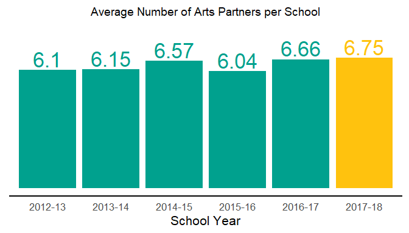

Note: These data are calculated from the “condensed” rubrics (i.e., 650 schools for SY 2017-18) and only include those schools that responded to the survey.

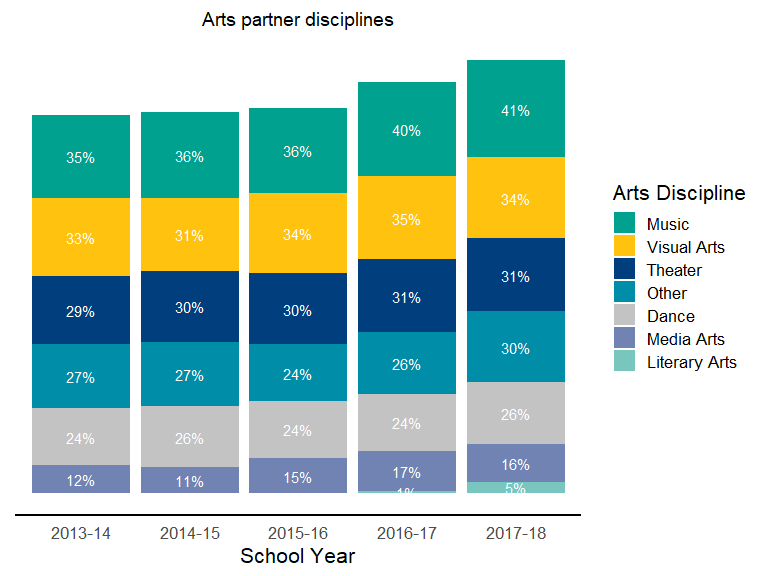

Note: partnership organizations may identify with more than one arts discipline, so total disciplines may add up to more than 100%.

#### Some sort of broader partner analysis will go here (TBA)

TBA. This section will include:

- Geographic trends, or
- Partners in 17-18 meeting requests from 16-17, or
- Geographic distribution of programmign types (to go in IV-B)

#### IV-B: Partnership programming

Jump back to top

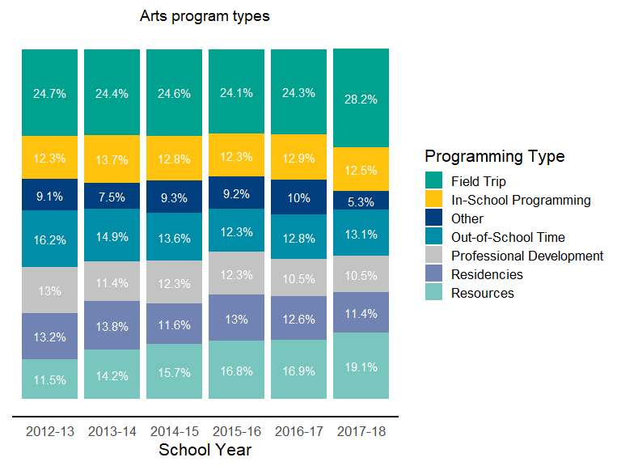

### Section 5: Network Analyses

Jump back to top

TBA

### Section 6: Funding

Jump back to top

TBA

### Section 7: Conclusion

Jump back to top

TBA